# Modeling Pulse Rate Using Demographic and Dietary Information

Patrick Wu

2020-12-10

# 1 Setup and Data Ingest

This study uses data from the 2017-2018 National Health and Nutrition Examination Survey to model pulse rate using various demographic and dietary characteristics.

## 1.1 R Setup

These code chunks specify options in R and load the necessary libraries.

```r
knitr::opts_chunk$set(comment=NA)
options(width = 70)
```

```r
library(naniar)
library(equatiomatic)
library(car)
library(GGally)
library(nhanesA)
library(readr)
library(readxl)
library(broom)
library(knitr)
library(tidyr)
library(magrittr)
library(tidyverse)

theme_set(theme_bw())

options(dplyr.summarise.inform = FALSE)
```

## 1.2 Data Ingest

First, the data must be pulled from the NHANES website. NHANES data are publicly available, and the data files are saved locally for easier access. The variables to be used in the analysis are selected from the data sets.

```r
#Pulling data from NHANES

#bp_raw <- nhanes('BPX_J') %>% tibble()

#saveRDS(bp_raw, "data/BPX_J.Rds")

#demo_raw <- nhanes('DEMO_J') %>% tibble()

#saveRDS(demo_raw, "data/DEMO_J.Rds")

#day1_raw <- nhanes('DR1TOT_J') %>% tibble()

#saveRDS(day1_raw, "data/DR1TOT_J.Rds")

#Data can now be read from saved RDS files

bp_raw <- readRDS("data/BPX_J.Rds")

demo_raw <- readRDS("data/DEMO_J.Rds")

day1_raw <- readRDS("data/DR1TOT_J.Rds")

#Selecting variables

demo <- demo_raw %>% select(SEQN, RIDSTATR, RIAGENDR, RIDRETH3, RIDAGEYR)

day1 <- day1_raw %>% select(SEQN, DR1TSODI, DR1TKCAL, DBQ095Z)

bp <- bp_raw %>% select(SEQN, BPXPLS)
```

Only dietary data from Day 1 is used as it is more complete. Therefore, some information is lost in the interest of applying a consistent analytical procedure to all subjects while maximizing sample size.

# 2 Merging the Data

The next step is to merge the data pulled from different NHANES files. The data files can be merged using the ID variable `SEQN`.

```r
#Merging datasets

temp1 <- left_join(demo, bp, by = "SEQN")

nhanesdata <- left_join(temp1, day1, by = "SEQN")
```

No difficulties were experienced in merging the data, and the data will be checked in more detail later on.

# 3 Cleaning the Data

The data documentation contains detailed information about the variables in the NHANES data set. Missing values will be removed for this analysis. In addition, one variable (`DBQ095Z`, the type of table salt used) contains a “Don’t Know” value that will also be treated as missing. Categorical variables are also made factors and the levels are renamed to reflect the identities of the categories. Finally, only subjects who participated in both the interview and examination portions of the survey are included, and empty levels and labels are removed.

```r
#Evaluating missingness and cleaning data

nhanesdata <- nhanesdata %>% mutate(DBQ095Z = na_if(DBQ095Z, "99"),
                                      sex = fct_recode(factor(RIAGENDR),
                                "Male" = "1",
                                "Female" = "2"),
                                RIDRETH3 = fct_recode(factor(RIDRETH3),
                                                      "Mexican American" = "1",
                                                      "Other Hispanic" = "2",
                                                      "Non-Hispanic White" = "3",
                                                      "Non-Hispanic Black" = "4",
                                                      "Non-Hispanic Asian" = "6",
                                                      "Other Race" = "7"),
                                RIDRETH3 = fct_relevel(RIDRETH3, "Non-Hispanic White"),
                                DBQ095Z = fct_recode(factor(DBQ095Z),
                                                     "Ordinary salt" = "1",
                                                     "Lite salt" = "2",
                                                     "Salt substitute" = "3",
                                                     "Doesn't use at table" = "4")) %>%
  filter(RIDSTATR == 2) %>% subset(select = -RIAGENDR)

miss_case_table(nhanesdata)
```

```
# A tibble: 5 x 3
  n_miss_in_case n_cases pct_cases
           <int>   <int>     <dbl>
1              0    6086    69.9
2              1    1391    16.0
3              2      10     0.115
4              3     792     9.10
5              4     425     4.88
```

```r
nhanes_comp <- na.omit(nhanesdata)

nhanes_comp <- nhanes_comp %>% droplevels() %>%
  haven::zap_label() %>%
  haven::zap_labels()

glimpse(nhanes_comp)
```

```
Rows: 6,086
Columns: 9
$ SEQN     <int> 93705, 93706, 93707, 93708, 93711, 93712, 93713,...
$ RIDSTATR <int> 2, 2, 2, 2, 2, 2, 2, 2, 2, 2, 2, 2, 2, 2, 2, 2, ...
$ RIDRETH3 <fct> Non-Hispanic Black, Non-Hispanic Asian, Other Ra...
$ RIDAGEYR <int> 66, 18, 13, 66, 56, 18, 67, 54, 71, 61, 22, 13, ...
$ BPXPLS   <int> 52, 82, 100, 68, 62, 68, 90, 90, 66, 58, 60, 66,...
$ DR1TSODI <int> 3574, 3657, 2450, 2135, 4382, 3753, 2456, 5000, ...
$ DR1TKCAL <int> 1202, 1987, 1775, 1251, 2840, 2045, 2040, 2493, ...
$ DBQ095Z  <fct> Doesn't use at table, Ordinary salt, Ordinary sa...
$ sex      <fct> Female, Male, Male, Female, Male, Male, Male, Fe...
```

Of a total of 8704 participants who underwent both the interview and the examination, 6086 with complete data are used in this analysis. The use of complete cases only requires an assumption that the data are missing completely at random.

# 4 My Research Question

The National Health and Nutrition Examination Survey is carried out on subjects selected using a stratified method from the US population. First, counties are divided into groups based on their characteristics and sampled randomly. Then, the counties are subdivided and these subdivisions are sampled. Then, a sample of households is selected from each selected subdivision and people from those households are randomly selected. The survey contains both an interview and a physical examination component – only subjects who participated in both are included in this study. The research question for this study is as follows:

How effectively can sodium intake be used to predict pulse rate, and how much is this prediction improved when considering other demographic and dietary characteristics including sex, race, age, caloric intake, and type of table salt used?

My expectation is that increasing sodium intake will be associated with increasing pulse rate, and that the use of additional predictors will improve the model significantly.

# 5 My Final Variables

## 5.1 Codebook

The subjects of this study are 6086 2017-2018 NHANES participants aged 8 to at least 80 with complete data on the variables listed below.

| Variable Name | Type | Description | Original Name |
| --- | --- | --- | --- |
| `SEQN` | - | Subject identifying code | - |
| `RIDSTATR` | - | Code 2 = Both interviewed and examined | - |
| `RIDRETH3` | 6-cat | Predictor; Race/ethnicity (Mexican American, Other Hispanic, Non-Hispanic White, Non-Hispanic Black, Non-Hispanic Asian, or Other Race) | - |
| `RIDAGEYR` | Quant | Predictor; Age in years (Values of 80 and over coded as 80) | - |
| `BPXPLS` | Quant | **Outcome**; Pulse rate in beats per minute (30s pulse * 2) | - |
| `DR1TSODI` | Quant | **Key predictor**; Total sodium intake for one day in mg calculated using USDA Food and Nutrient Database for Dietary Studies | - |
| `DR1TKCAL` | Quant | Predictor; Total caloric intake for one day in kcal calculated using USDA Food and Nutrient Database for Dietary Studies | - |
| `DBQ095Z` | 4-cat | Predictor; Type of table salt used (Ordinary, lite, salt substitute, or doesn’t use) | - |
| `sex` | Binary | Predictor; Sex (Male or female) | `RIAGENDR` |

## 5.2 Numerical Data Description

```r
str(nhanes_comp)
```

```
tibble [6,086 x 9] (S3: tbl_df/tbl/data.frame)
 $ SEQN    : 'labelled' int [1:6086] 93705 93706 93707 93708 93711 93712 93713 93714 93715 93716 ...
 $ RIDSTATR: 'labelled' int [1:6086] 2 2 2 2 2 2 2 2 2 2 ...
 $ RIDRETH3: Factor w/ 6 levels "Non-Hispanic White",..: 4 5 6 5 5 2 1 4 6 5 ...
 $ RIDAGEYR: 'labelled' int [1:6086] 66 18 13 66 56 18 67 54 71 61 ...
 $ BPXPLS  : 'labelled' int [1:6086] 52 82 100 68 62 68 90 90 66 58 ...
 $ DR1TSODI: 'labelled' int [1:6086] 3574 3657 2450 2135 4382 3753 2456 5000 1430 4831 ...
 $ DR1TKCAL: 'labelled' int [1:6086] 1202 1987 1775 1251 2840 2045 2040 2493 1287 2917 ...
 $ DBQ095Z : Factor w/ 4 levels "Ordinary salt",..: 4 1 1 4 1 1 1 1 1 1 ...
 $ sex     : Factor w/ 2 levels "Male","Female": 2 1 1 2 1 1 1 2 1 1 ...
 - attr(*, "na.action")= 'omit' Named int [1:2618] 1 2 7 8 16 18 22 23 28 34 ...
  ..- attr(*, "names")= chr [1:2618] "1" "2" "7" "8" ...
```

```r
Hmisc::describe(nhanes_comp)
```

```
nhanes_comp

 9  Variables      6086  Observations
----------------------------------------------------------------------
SEQN
       n  missing distinct     Info     Mean      Gmd      .05
    6086        0     6086        1    98327     3091    94155
     .10      .25      .50      .75      .90      .95
   94625    95998    98362   100629   102057   102499

lowest :  93705  93706  93707  93708  93711
highest: 102952 102953 102954 102955 102956
----------------------------------------------------------------------
RIDSTATR
       n  missing distinct     Info     Mean      Gmd
    6086        0        1        0        2        0

Value         2
Frequency  6086
Proportion    1
----------------------------------------------------------------------
RIDRETH3
       n  missing distinct
    6086        0        6

lowest : Non-Hispanic White Mexican American   Other Hispanic     Non-Hispanic Black Non-Hispanic Asian
highest: Mexican American   Other Hispanic     Non-Hispanic Black Non-Hispanic Asian Other Race

Value      Non-Hispanic White   Mexican American     Other Hispanic
Frequency                2116                860                530
Proportion              0.348              0.141              0.087

Value      Non-Hispanic Black Non-Hispanic Asian         Other Race
Frequency                1436                754                390
Proportion              0.236              0.124              0.064
----------------------------------------------------------------------
RIDAGEYR
       n  missing distinct     Info     Mean      Gmd      .05
    6086        0       73        1    41.82    25.79       10
     .10      .25      .50      .75      .90      .95
```

[output cut: 33 more lines]

```
Frequency                  4169                   90
Proportion                0.685                0.015

Value           Salt substitute Doesn't use at table
Frequency                    64                 1763
Proportion                0.011                0.290
----------------------------------------------------------------------
sex
       n  missing distinct
    6086        0        2

Value        Male Female
Frequency    2983   3103
Proportion   0.49   0.51
----------------------------------------------------------------------
```

- There is no missing data for any variable. Subjects with missing data were dropped from the data set on the assumption that data were missing completely at random.
- Ranges for all quantitative variables were checked. There are some extreme values for sodium and calorie intake. However, after consideration, I believe these values are plausible and will not modify or exclude them.
- All categorical variables have 2-6 levels, and are included as factors. All levels have at least 64 subjects.
- All subjects were included in both the questionnaire and examination. Subjects range in age from 8 to at least 80.

# 6 Partitioning the Data

The next step is to partition the data into a training sample, containing about 80% of the data, and a test sample, containing the other 20% of the data.

```r
set.seed(12252020)

nhanes_train <- nhanes_comp %>%
  slice_sample(., prop = 0.80)
nhanes_test <- anti_join(nhanes_comp, nhanes_train, by = "SEQN")

dim(nhanes_train)
```

```
[1] 4868    9
```

```r
dim(nhanes_test)
```

```
[1] 1218    9
```

The training sample will be used to build the models. Performance in both the training sample and the test sample will be used to evaluate the models.

# 7 Transforming the Outcome

The next step is to examine the distributions of the variables and consider transformations. The first variable to consider is the outcome, pulse rate.

[figure not shown]

```r
ggplot(nhanes_train, aes(x = BPXPLS)) +
  geom_histogram(color = "purple", fill = "lightblue", bins = 25) +
  guides(fill = FALSE) +
  labs(title = "Pulse rate looks righ-skewed",
       subtitle = "n = 6086 2017-2018 NHANES Participants",
       x = "Pulse rate, bpm")
```

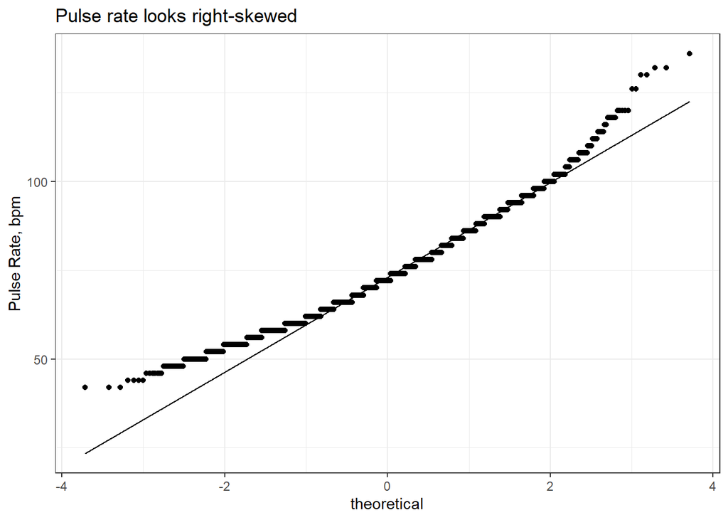

```r
ggplot(nhanes_train, aes(sample = BPXPLS)) +
  geom_qq() + geom_qq_line() +
  guides(col = FALSE) +
  labs(y = "Pulse Rate, bpm",
       title = "Pulse rate looks right-skewed")
```

The distribution of pulse rate is noticeably right-skewed.

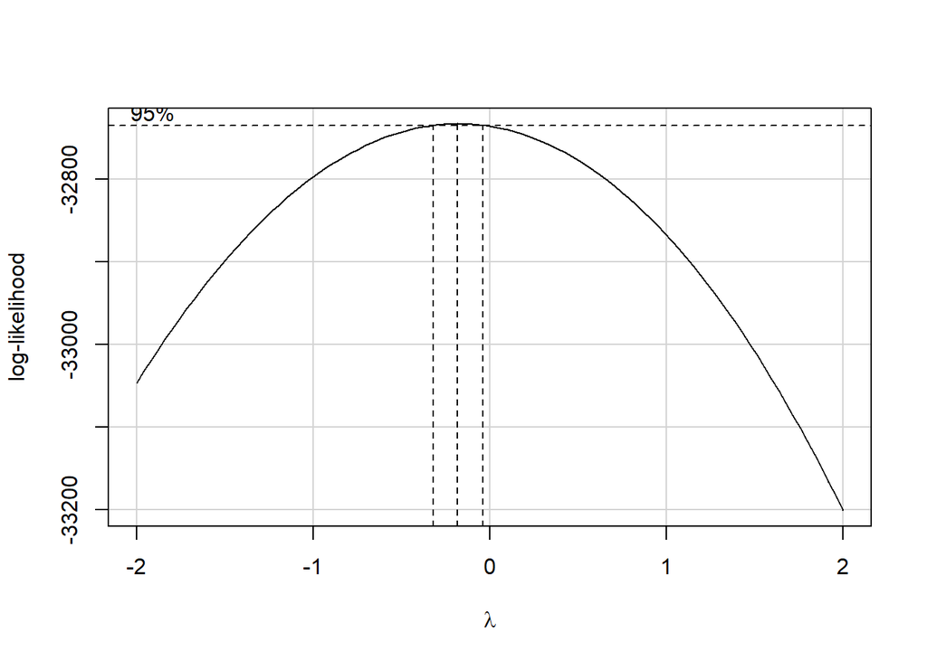

```r
mod_box <- lm(BPXPLS ~ DR1TSODI, data = nhanes_train)

mod_box2 <- lm(BPXPLS ~ DR1TSODI + RIDRETH3 + RIDAGEYR + DR1TKCAL + DBQ095Z + sex, data = nhanes_train)

boxCox(mod_box)
```

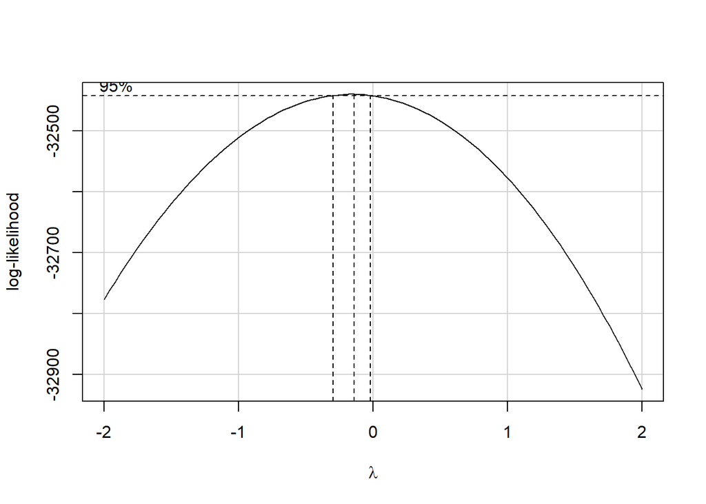

```r
boxCox(mod_box2)
```

The Box-Cox plots suggest a log transformation.

[figure not shown]

```r
ggplot(nhanes_train, aes(x = log(BPXPLS))) +
  geom_histogram(color = "purple", fill = "lightblue", bins = 25) +
  guides(fill = FALSE) +
  labs(title = "Log transformation looks more normal",
       subtitle = "n = 6086 2017-2018 NHANES Participants",
       x = "Log of Pulse rate")
```

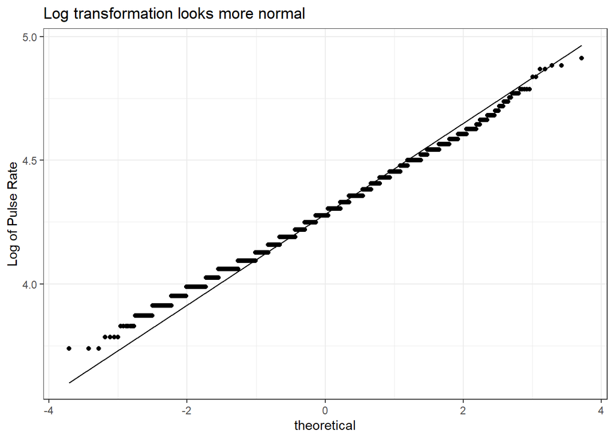

```r
ggplot(nhanes_train, aes(sample = log(BPXPLS))) +
  geom_qq() + geom_qq_line() +
  guides(col = FALSE) +
  labs(y = "Log of Pulse Rate",
       title = "Log transformation looks more normal")
```

The distribution for the outcome after applying a log transformation looks much better. This transformation will be used in fitting the models.

```r
# Numerical summary of outcome and predictor variables

nhanes_train <- nhanes_train %>% mutate(logBPXPLS = log(BPXPLS))

nhanes_train %>% select(-SEQN, -RIDSTATR, -BPXPLS) %>% Hmisc::describe()
```

```
.

 7  Variables      4868  Observations
----------------------------------------------------------------------
RIDRETH3
       n  missing distinct
    4868        0        6

lowest : Non-Hispanic White Mexican American   Other Hispanic     Non-Hispanic Black Non-Hispanic Asian
highest: Mexican American   Other Hispanic     Non-Hispanic Black Non-Hispanic Asian Other Race

Value      Non-Hispanic White   Mexican American     Other Hispanic
Frequency                1693                701                429
Proportion              0.348              0.144              0.088

Value      Non-Hispanic Black Non-Hispanic Asian         Other Race
Frequency                1136                598                311
Proportion              0.233              0.123              0.064
----------------------------------------------------------------------
RIDAGEYR
       n  missing distinct     Info     Mean      Gmd      .05
    4868        0       73        1    41.85    25.84       10
     .10      .25      .50      .75      .90      .95
      12       20       42       61       73       79

lowest :  8  9 10 11 12, highest: 76 77 78 79 80
----------------------------------------------------------------------
DR1TSODI
       n  missing distinct     Info     Mean      Gmd      .05
    4868        0     3284        1     3405     1944     1168
     .10      .25      .50      .75      .90      .95
    1481     2115     3060     4244     5739     6758

lowest :     0     9    22    23    41, highest: 16031 16573 18073 20536 20799
----------------------------------------------------------------------
DR1TKCAL
       n  missing distinct     Info     Mean      Gmd      .05
    4868        0     2569        1     2091     1062    821.4
     .10      .25      .50      .75      .90      .95
  1023.0   1406.0   1927.0   2595.2   3355.6   3889.3
```

[output cut: 17 more lines]

```
    4868        0        2

Value        Male Female
Frequency    2382   2486
Proportion  0.489  0.511
----------------------------------------------------------------------
logBPXPLS
       n  missing distinct     Info     Mean      Gmd      .05
    4868        0       44    0.997    4.285   0.1859    4.025
     .10      .25      .50      .75      .90      .95
   4.060    4.159    4.277    4.407    4.500    4.543

lowest : 3.737670 3.784190 3.828641 3.871201 3.912023
highest: 4.787492 4.836282 4.867534 4.882802 4.912655
----------------------------------------------------------------------
```

The numerical summary of the data shows that although some extreme values are present, most values of sodium and caloric intake fall within a reasonable range. Most subjects are non-Hispanic white or non-Hispanic black and use ordinary table salt, with a fairly even split between male and female sex.

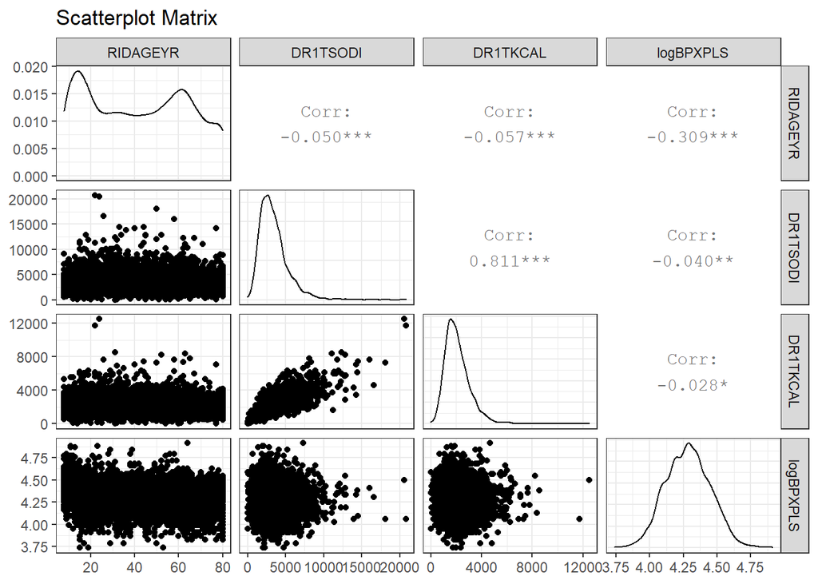

```r
nhanes_train %>% select(RIDAGEYR, DR1TSODI, DR1TKCAL, logBPXPLS) %>%
  ggpairs(., title = "Scatterplot Matrix",
          lower = list(combo = wrap("facethist", bins = 20)))
```

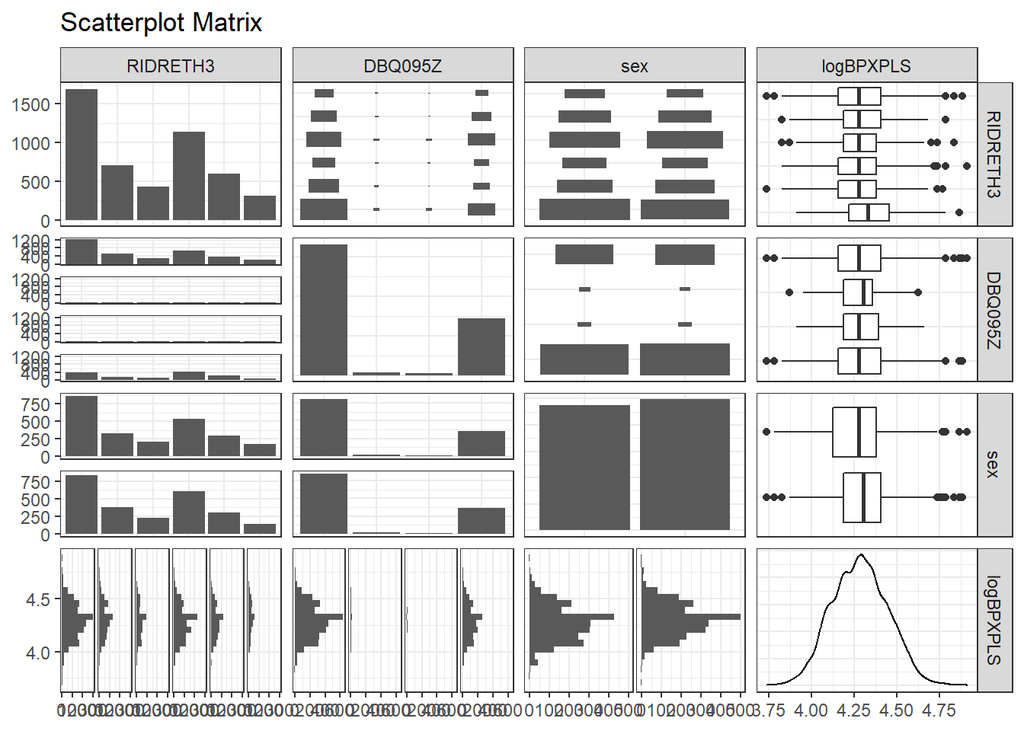

```r
nhanes_train %>% select(RIDRETH3, DBQ095Z, sex, logBPXPLS) %>%
  ggpairs(., title = "Scatterplot Matrix",
          lower = list(combo = wrap("facethist", bins = 20)))
```

The scatterplot matrix shows that sodium intake and caloric intake are highly right-skewed, as indicated by the numerical summaries. The strongest correlation between quantitative variables is between these two variables, which seems logical. Interestingly, age, sodium intake, and caloric intake all exhibit a negative correlation with pulse rate, with age having the strongest relationship.

For the categorical variables, there is not much noticeable variation in any of the variables divided by any other. There is also no notable collinearity between predictors in the matrices.

```r
mosaic::favstats(logBPXPLS ~ RIDRETH3, data = nhanes_train)
```

```
            RIDRETH3      min       Q1   median       Q3      max
1 Non-Hispanic White 3.737670 4.158883 4.276666 4.406719 4.882802
2   Mexican American 3.828641 4.189655 4.276666 4.406719 4.787492
3     Other Hispanic 3.828641 4.189655 4.276666 4.382027 4.836282
4 Non-Hispanic Black 3.828641 4.158883 4.276666 4.382027 4.912655
5 Non-Hispanic Asian 3.737670 4.158883 4.276666 4.382027 4.770685
6         Other Race 3.912023 4.219508 4.330733 4.454347 4.867534
      mean        sd    n missing
1 4.285456 0.1693873 1693       0
2 4.292148 0.1606851  701       0
3 4.281687 0.1611046  429       0
4 4.273644 0.1630255 1136       0
5 4.275680 0.1574746  598       0
6 4.323433 0.1652788  311       0
```

```r
mosaic::favstats(logBPXPLS ~ DBQ095Z, data = nhanes_train)
```

```
               DBQ095Z      min       Q1   median       Q3      max
1        Ordinary salt 3.737670 4.158883 4.276666 4.406719 4.912655
2            Lite salt 3.871201 4.189655 4.304065 4.356709 4.624973
3      Salt substitute 3.912023 4.189655 4.276666 4.394373 4.663439
4 Doesn't use at table 3.737670 4.158883 4.276666 4.406719 4.882802
      mean        sd    n missing
1 4.286139 0.1635705 3312       0
2 4.281418 0.1566397   77       0
3 4.288055 0.1589873   51       0
4 4.280931 0.1676778 1428       0
```

The numerical summaries do not show any notable differences in pulse rate across racial or table salt categories, beyond perhaps slightly higher pulse rates in the Other Race group.

# 8 The Big Model

This step will fit a model containing all the predictor variables.

```r
mbig <- lm(logBPXPLS ~ DR1TSODI + RIDAGEYR + DR1TKCAL + RIDRETH3 + DBQ095Z + sex, data = nhanes_train)

summary(mbig)
```

```
Call:
lm(formula = logBPXPLS ~ DR1TSODI + RIDAGEYR + DR1TKCAL + RIDRETH3 +
    DBQ095Z + sex, data = nhanes_train)

Residuals:
     Min       1Q   Median       3Q      Max
-0.63875 -0.10578 -0.00467  0.10308  0.72006

Coefficients:
                              Estimate Std. Error t value Pr(>|t|)
(Intercept)                  4.375e+00  8.672e-03 504.544  < 2e-16
DR1TSODI                    -3.753e-06  2.044e-06  -1.836 0.066383
RIDAGEYR                    -2.297e-03  1.011e-04 -22.720  < 2e-16
DR1TKCAL                     3.157e-06  3.838e-06   0.822 0.410848
RIDRETH3Mexican American    -1.439e-02  7.032e-03  -2.047 0.040733
RIDRETH3Other Hispanic      -1.342e-02  8.398e-03  -1.598 0.110051
RIDRETH3Non-Hispanic Black  -2.308e-02  6.004e-03  -3.845 0.000122
RIDRETH3Non-Hispanic Asian  -2.033e-02  7.464e-03  -2.724 0.006479
RIDRETH3Other Race           1.131e-02  9.658e-03   1.171 0.241681
DBQ095ZLite salt             8.551e-03  1.790e-02   0.478 0.632809
DBQ095ZSalt substitute       2.950e-02  2.195e-02   1.344 0.179051
DBQ095ZDoesn't use at table  7.299e-03  4.994e-03   1.462 0.143925
sexFemale                    3.772e-02  4.629e-03   8.149 4.62e-16

(Intercept)                 ***
DR1TSODI                    .
RIDAGEYR                    ***
DR1TKCAL
RIDRETH3Mexican American    *
RIDRETH3Other Hispanic
RIDRETH3Non-Hispanic Black  ***
RIDRETH3Non-Hispanic Asian  **
RIDRETH3Other Race
DBQ095ZLite salt
DBQ095ZSalt substitute
DBQ095ZDoesn't use at table
sexFemale                   ***
---
Signif. codes:  0 '***' 0.001 '**' 0.01 '*' 0.05 '.' 0.1 ' ' 1

Residual standard error: 0.1551 on 4855 degrees of freedom
Multiple R-squared:  0.1148,    Adjusted R-squared:  0.1126
F-statistic: 52.46 on 12 and 4855 DF,  p-value: < 2.2e-16
```

The big model has an R-squared value of 0.115, which is disappointing considering the number of variables used. This is reflected in the adjusted R-squared value being lower than the multiple R-squared value. Age and sex were the variables with the most significant P-values.

```r
tidy(mbig, conf.int = TRUE, conf.level = 0.90) %>%
  filter(abs(estimate) > 0.0001) %>%
  select(term, estimate, std.error, conf.low, conf.high, p.value) %>%
  kable(dig = 4)
```

| term | estimate | std.error | conf.low | conf.high | p.value |
| --- | --- | --- | --- | --- | --- |
| (Intercept) | 4.3754 | 0.0087 | 4.3612 | 4.3897 | 0.0000 |
| RIDAGEYR | -0.0023 | 0.0001 | -0.0025 | -0.0021 | 0.0000 |
| RIDRETH3Mexican American | -0.0144 | 0.0070 | -0.0260 | -0.0028 | 0.0407 |
| RIDRETH3Other Hispanic | -0.0134 | 0.0084 | -0.0272 | 0.0004 | 0.1101 |
| RIDRETH3Non-Hispanic Black | -0.0231 | 0.0060 | -0.0330 | -0.0132 | 0.0001 |
| RIDRETH3Non-Hispanic Asian | -0.0203 | 0.0075 | -0.0326 | -0.0080 | 0.0065 |
| RIDRETH3Other Race | 0.0113 | 0.0097 | -0.0046 | 0.0272 | 0.2417 |
| DBQ095ZLite salt | 0.0086 | 0.0179 | -0.0209 | 0.0380 | 0.6328 |
| DBQ095ZSalt substitute | 0.0295 | 0.0220 | -0.0066 | 0.0656 | 0.1791 |
| DBQ095ZDoesn’t use at table | 0.0073 | 0.0050 | -0.0009 | 0.0155 | 0.1439 |
| sexFemale | 0.0377 | 0.0046 | 0.0301 | 0.0453 | 0.0000 |

The intercept of the model is 4.38 with a 90% confidence interval of 4.36 to 4.39. This corresponds to the expected value for the log of the pulse rate of a person who is non-Hispanic White, non-female, uses ordinary table salt, and has no sodium or caloric intake and an age of zero.

The coefficient for age is -0.0023 with a 90% confidence interval of -0.0025 to -0.0021. This value corresponds to the change in log of pulse rate expected with an increase in age of 1 year, assuming all other variables are held constant. The confidence interval indicates that increasing age is associated with a decrease in pulse rate at the 10% significance level when accounting for the other factors in the model.

The coefficient for “Mexican American” is -0.0144 with a 90% confidence interval of -0.0260 to -0.0028. This value corresponds to the difference in log of pulse rate expected between Mexican Americans and non-Hispanic Whites if all other variables are the same. The confidence interval indicates that the mean pulse rate for Mexican Americans is lower than that of non-Hispanic whites at a 10% significance level when accounting for the other factors in the model.

The coefficient for “Other Hispanic” is -0.0134 with a 90% confidence interval of -0.0272 to 0.0004. This value corresponds to the difference in log of pulse rate expected between people in the “Other Hispanic” category and the “non-Hispanic White” category if all other variables are the same. The confidence interval indicates that the mean pulse rate for other Hispanics is not detectably different from that of non-Hispanic Whites at a 10% significance level when accounting for the other factors in the model.

The coefficient for “Non-Hispanic Black” is -0.0231 with a 90% confidence interval of -0.0330 to -0.0132. This value corresponds to the difference in log of pulse rate expected between people in the “Non-Hispanic Black” category and the “Non-Hispanic White” category if all other variables values are the same. The confidence interval indicates that the mean pulse rate for non-Hispanic Black participants is lower than that of non-Hispanic White participants at a 10% significance level when accounting for the other factors in the model.

The coefficient for “Non-Hispanic Asian” is -0.0203 with a 90% confidence interval of -0.0326 to -0.0080. This value corresponds to the difference in log of pulse rate expected between people in the “Non-Hispanic Asian” category and the “Non-Hispanic White” category if all other variables values are the same. The confidence interval indicates that the mean pulse rate for non-Hispanic Asian participants is lower than that of non-Hispanic White participants at a 10% significance level when accounting for the other factors in the model.

The coefficient for “Other Race” is 0.0113 with a 90% confidence interval of -0.0046 to 0.0272. This value corresponds to the difference in log of pulse rate expected between people in the “Other Race” category and the “Non-Hispanic White” category if all other variables values are the same. The confidence interval indicates that the mean pulse rate for people in the “Other Race” category is not detectably different from that of non-Hispanic White participants at a 10% significance level when accounting for the other factors in the model.

The coefficient for “Lite salt” is 0.0086 with a 90% confidence interval of -0.0209 to 0.0380. This value corresponds to the difference in log of pulse rate expected between people using lite table salt and people using ordinary table salt if all other variables values are the same. The confidence interval indicates that the mean pulse rate for people using lite table salt is not detectably different from that of people using ordinary table salt at a 10% significance level when accounting for the other factors in the model.

The coefficient for “Salt substitute” is 0.0295 with a 90% confidence interval of -0.0066 to 0.0656. This value corresponds to the difference in log of pulse rate expected between people using salt substitute and people using ordinary table salt if all other variables values are the same. The confidence interval indicates that the mean pulse rate for people using salt substitute is not detectably different from that of people using ordinary table salt at a 10% significance level when accounting for the other factors in the model.

The coefficient for “Doesn’t use” is 0.0073 with a 90% confidence interval of -0.0009 to 0.0155. This value corresponds to the difference in log of pulse rate expected between people who do not use table salt and people using ordinary table salt if all other variables values are the same. The confidence interval indicates that the mean pulse rate for people who do not use table salt is not detectably different from that of people using ordinary table salt at a 10% significance level when accounting for the other factors in the model.

The coefficient for sex is 0.0377 with a 90% confidence interval of 0.0301 to 0.0453. This value corresponds to the difference in log of pulse rate expected between females and non-females assuming all other variable values are the same. The confidence interval indicates that the mean pulse rate for females is higher than the mean pulse rate for non-females at a 10% significance level when accounting for the other factors in the model.

```r
tidy(mbig, conf.int = TRUE, conf.level = 0.90) %>%
  filter(abs(estimate) < 0.0001) %>%
  select(term, estimate, std.error, conf.low, conf.high, p.value) %>%
  kable(dig = 7)
```

| term | estimate | std.error | conf.low | conf.high | p.value |
| --- | --- | --- | --- | --- | --- |
| DR1TSODI | -3.8e-06 | 2.0e-06 | -7.1e-06 | -4.0e-07 | 0.0663832 |
| DR1TKCAL | 3.2e-06 | 3.8e-06 | -3.2e-06 | 9.5e-06 | 0.4108477 |

The coefficients for sodium and calorie intake are much smaller in magnitude than the others. This makes sense since the effect sizes are scaled to a change in sodium intake of 1 mg per day and a change in caloric intake of 1 kcal per day.

The coefficient for sodium intake is -0.0000038 with a 90% confidence interval of -0.0000071 to -0.0000004. This value corresponds to the change in log of pulse rate expected with an increase in daily sodium intake of 1 mg, assuming all other variables are held constant. The confidence interval indicates that increasing sodium intake is associated with decreasing pulse rate at the 10% significance level when accounting for the other factors in the model. This is the opposite of the relationship that was expected.

The coefficient for caloric intake is 0.0000032 with a 90% confidence interval of -0.0000032 to 0.0000095. This value corresponds to the change in log of pulse rate expected with an increase in daily calorie intake of 1 kcal, assuming all other variables are held constant. The confidence interval indicates that increasing caloric intake is not detectably associated with pulse rate at the 10% significance level when accounting for the other factors in the model.

```r
extract_eq(mbig, use_coefs = TRUE, coef_digits = 7,
           terms_per_line = 2, wrap = TRUE, ital_vars = TRUE)
```

$$\begin{aligned}
logBPXPLS &= 4.3754487 - 3.8e-06(DR1TSODI)\ - \\
&\quad 0.0022973(RIDAGEYR) + 3.2e-06(DR1TKCAL)\ - \\
&\quad 0.0143925(RIDRETH3_{Mexican\ American}) - 0.0134229(RIDRETH3_{Other\ Hispanic})\ - \\
&\quad 0.0230849(RIDRETH3_{Non-Hispanic\ Black}) - 0.0203288(RIDRETH3_{Non-Hispanic\ Asian})\ + \\
&\quad 0.0113084(RIDRETH3_{Other\ Race}) + 0.0085513(DBQ095Z_{Lite\ salt})\ + \\
&\quad 0.0294982(DBQ095Z_{Salt\ substitute}) + 0.0072992(DBQ095Z_{Doesn't\ use\ at\ table})\ + \\
&\quad 0.03772(sex_{Female}) + \epsilon
\end{aligned}$$

Putting all the coefficients together produces the equation displayed above.

# 9 The Smaller Model

For the smaller model, the key predictor (sodium intake) will be used, along with age and sex. These additional predictors were selected due to their significance in the previous model.

```r
msmall <- lm(logBPXPLS ~ DR1TSODI + RIDAGEYR + sex, data = nhanes_train)

summary(msmall)
```

```
Call:
lm(formula = logBPXPLS ~ DR1TSODI + RIDAGEYR + sex, data = nhanes_train)

Residuals:
     Min       1Q   Median       3Q      Max
-0.62836 -0.10682 -0.00425  0.10367  0.70684

Coefficients:
              Estimate Std. Error t value Pr(>|t|)
(Intercept)  4.370e+00  7.216e-03 605.559  < 2e-16 ***
DR1TSODI    -2.577e-06  1.226e-06  -2.102   0.0356 *
RIDAGEYR    -2.271e-03  9.940e-05 -22.846  < 2e-16 ***
sexFemale    3.602e-02  4.586e-03   7.856 4.86e-15 ***
---
Signif. codes:  0 '***' 0.001 '**' 0.01 '*' 0.05 '.' 0.1 ' ' 1

Residual standard error: 0.1554 on 4864 degrees of freedom
Multiple R-squared:  0.1098,    Adjusted R-squared:  0.1092
F-statistic: 199.9 on 3 and 4864 DF,  p-value: < 2.2e-16
```

The small model has an R-squared value of 0.110, marginally lower than the big model. The adjusted R-squared is now closer to the R-squared, although still lower. Age and sex again have the lowest P-values.

```r
tidy(msmall, conf.int = TRUE, conf.level = 0.90) %>%
  select(term, estimate, std.error, conf.low, conf.high, p.value) %>%
  kable(dig = 7)
```

| term | estimate | std.error | conf.low | conf.high | p.value |
| --- | --- | --- | --- | --- | --- |
| (Intercept) | 4.3699719 | 0.0072164 | 4.3580996 | 4.3818441 | 0.0000000 |
| DR1TSODI | -0.0000026 | 0.0000012 | -0.0000046 | -0.0000006 | 0.0356108 |
| RIDAGEYR | -0.0022708 | 0.0000994 | -0.0024344 | -0.0021073 | 0.0000000 |
| sexFemale | 0.0360250 | 0.0045858 | 0.0284805 | 0.0435695 | 0.0000000 |

The intercept of the model is 4.37 with a 90% confidence interval of 4.36 to 4.38. This corresponds to the expected value for the log of the pulse rate of a non-female person with no sodium intake and an age of zero.

The coefficient for sodium intake is -0.0000026 with a 90% confidence interval of -0.0000046 to -0.0000006. This value corresponds to the change in log of pulse rate expected with an increase in daily sodium intake of 1 mg, assuming all other variables in the model are held constant. The confidence interval indicates that increasing sodium intake is associated with decreasing pulse rate at the 10% significance level when accounting for the other factors in the model.

The coefficient for age is -0.0023 with a 90% confidence interval of -0.0024 to -0.0021. This value corresponds to the change in log of pulse rate expected with an increase in age of 1 year, assuming all other variables in the model are held constant. The confidence interval indicates that increasing age is associated with a decrease in pulse rate at the 10% significance level when accounting for the other factors in the model.

The coefficient for sex is 0.0360 with a 90% confidence interval of 0.0285 to 0.0436. This value corresponds to the difference in log of pulse rate expected between females and non-females assuming all other variables in the model are held constant. The confidence interval indicates that the mean pulse rate for females is higher than the mean pulse rate for non-females at a 10% significance level when accounting for the other factors in the model

```r
extract_eq(msmall, use_coefs = TRUE, coef_digits = 7,
           terms_per_line = 2, wrap = TRUE, ital_vars = TRUE)
```

$$\begin{aligned}
logBPXPLS &= 4.3699719 - 2.6e-06(DR1TSODI)\ - \\
&\quad 0.0022708(RIDAGEYR) + 0.036025(sex_{Female})\ + \\
&\quad \epsilon
\end{aligned}$$

Putting all the coefficients together produces the equation displayed above.

# 10 In-Sample Comparison

In this section the performance of the two models in the training sample will be compared.

## 10.1 Quality of Fit

```r
temp_a <- glance(mbig) %>%
  select(-logLik, -deviance) %>%
  round(digits = 3) %>%
  mutate(modelname = "big")

temp_b <- glance(msmall) %>%
  select(-logLik, -deviance) %>%
  round(digits = 3) %>%
  mutate(modelname = "small")

training_comp <- bind_rows(temp_a, temp_b) %>%
  select(modelname, nobs, df, AIC, BIC, everything())

training_comp %>% kable(dig=3)
```

| modelname | nobs | df | AIC | BIC | r.squared | adj.r.squared | sigma | statistic | p.value | df.residual |
| --- | --- | --- | --- | --- | --- | --- | --- | --- | --- | --- |
| big | 4868 | 12 | -4317.707 | -4226.841 | 0.115 | 0.113 | 0.155 | 52.463 | 0 | 4855 |
| small | 4868 | 3 | -4308.196 | -4275.744 | 0.110 | 0.109 | 0.155 | 199.921 | 0 | 4864 |

The adjusted R-squared for the big model is slightly larger than the adjusted R-squared for the small model. The values for the residual standard deviation, or sigma, are essentially the same.

The big model has the lower AIC, while the small model has the lower BIC.

Overall, the big model arguably performs better in the training sample when evaluating quality-of-fit measures, but the difference between the two models is not large.

## 10.2 Assessing Assumptions

### 10.2.1 Residual Plots for the Big Model

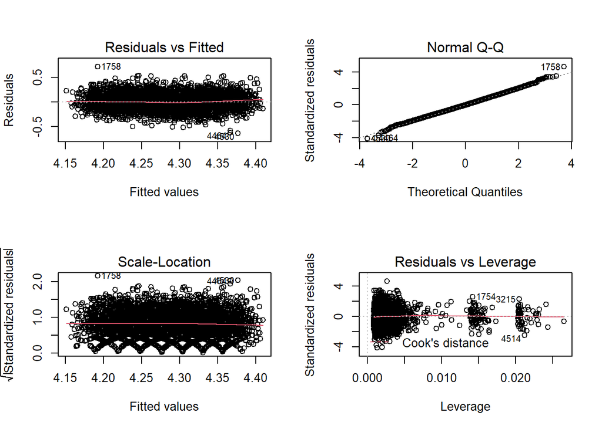

```r
par(mfrow = c(2,2)); plot(mbig); par(mfrow = c(1,1))
```

The residual plots for the big model do not show any issues with linearity, constant variance, or normality.

### 10.2.2 Residual Plots for the Small Model

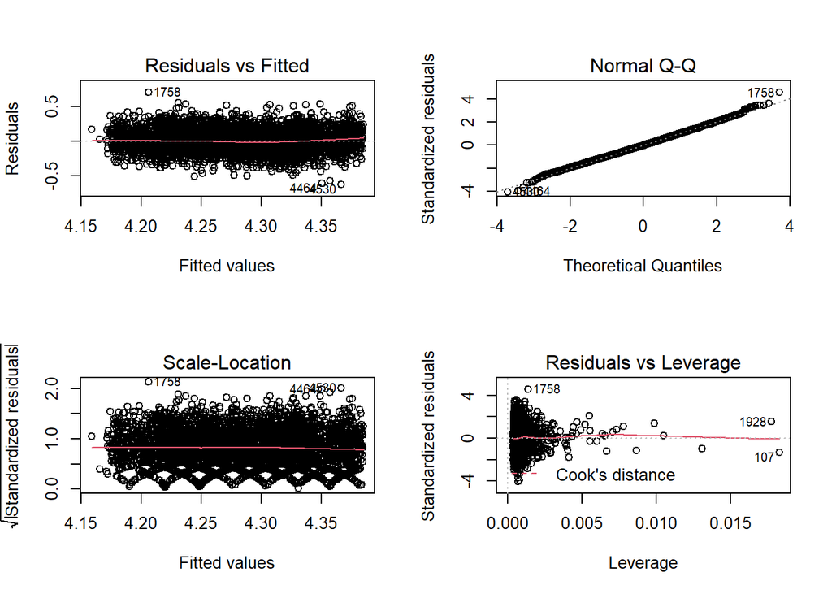

```r
par(mfrow = c(2,2)); plot(msmall); par(mfrow = c(1,1))
```

The residual plots for the small model do not show any issues with linearity, constant variance, or normality.

### 10.2.3 Collinearity

```r
vif(mbig)
```

```
             GVIF Df GVIF^(1/(2*Df))
DR1TSODI 2.964615  1        1.721806
RIDAGEYR 1.041722  1        1.020648
DR1TKCAL 3.027569  1        1.739991
RIDRETH3 1.067801  5        1.006582
DBQ095Z  1.041992  3        1.006879
sex      1.083958  1        1.041133
```

There do not appear to be major collinearity concerns. The largest source of collinearity seems to be the correlation between sodium intake and caloric intake, which is not an issue for the small model as caloric intake is excluded from that model.

## 10.3 Comparing the Models

Overall, I think the analyses conducted so far slightly favor the small model, since it avoids any issues with collinearity while only performing slightly worse on adjusted R-squared and AIC, and performing better on BIC.

# 11 Model Validation

## 11.1 Calculating Prediction Errors

In this section, both models are applied to the test sample and the predictions are transformed back into pulse rate values so that residuals can be calculated.

```r
aug_big <- augment(mbig, newdata = nhanes_test) %>%
  mutate(mod_name = "big",
         BPXPLS_fit = exp(.fitted),
         BPXPLS_res = BPXPLS - BPXPLS_fit) %>%
  select(SEQN, mod_name, BPXPLS, BPXPLS_fit, BPXPLS_res, everything())

aug_small <- augment(msmall, newdata = nhanes_test) %>%
  mutate(mod_name = "small",
         BPXPLS_fit = exp(.fitted),
         BPXPLS_res = BPXPLS - BPXPLS_fit) %>%
  select(SEQN, mod_name, BPXPLS, BPXPLS_fit, BPXPLS_res, everything())

test_comp <- union(aug_big, aug_small) %>%
  arrange(SEQN, mod_name)
```

## 11.2 Visualizing the Predictions

The predictions of each model can now be visualized and compared.

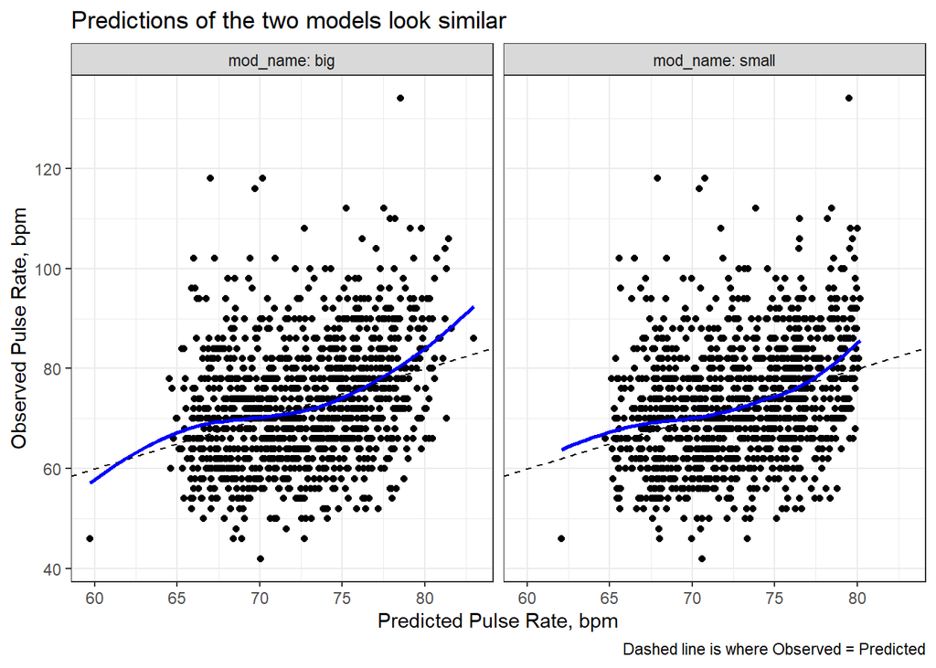

```r
ggplot(test_comp, aes(x = BPXPLS_fit, y = BPXPLS)) +
  geom_point() +
  geom_abline(slope = 1, intercept = 0, lty = "dashed") +
  geom_smooth(method = "loess", col = "blue", se = FALSE, formula = y ~ x) +
  facet_wrap( ~ mod_name, labeller = "label_both") +
  labs(x = "Predicted Pulse Rate, bpm",
       y = "Observed Pulse Rate, bpm",
       title = "Predictions of the two models look similar",
       caption = "Dashed line is where Observed = Predicted")
```

The predictions of the two models look similar overall. However, the predictions for the small model seem to be somewhat more clustered together, with a smaller range of predicted values. As a result, the loess smooth for the small model seems to adhere to the dashed line representing correct predictions slightly better.

## 11.3 Summarizing the Errors

```r
test_comp %>%
  group_by(mod_name) %>%
  summarize(n = n(),
            MAPE = mean(abs(BPXPLS_res)),
            RMSPE = sqrt(mean(BPXPLS_res^2)),
            max_error = max(abs(BPXPLS_res))) %>%
  kable(dig=3)
```

| mod_name | n | MAPE | RMSPE | max_error |
| --- | --- | --- | --- | --- |
| big | 1218 | 8.925 | 11.355 | 55.460 |
| small | 1218 | 8.976 | 11.389 | 54.505 |

The big model has a lower mean absolute prediction error and root mean squared prediction error, while the small model has the lower maximum absolute error.

### 11.3.1 The Largest Errors

```r
maxerr1 <- aug_big %>%
  filter(abs(BPXPLS_res) == max(abs(BPXPLS_res))) %>%
  select(-RIDSTATR, -.fitted)

maxerr2 <- aug_small %>%
  filter(abs(BPXPLS_res) == max(abs(BPXPLS_res))) %>%
  select(-RIDSTATR, -.fitted)

bind_rows(maxerr1, maxerr2) %>% kable(dig=3)
```

| SEQN | mod_name | BPXPLS | BPXPLS_fit | BPXPLS_res | RIDRETH3 | RIDAGEYR | DR1TSODI | DR1TKCAL | DBQ095Z | sex |
| --- | --- | --- | --- | --- | --- | --- | --- | --- | --- | --- |
| 96919 | big | 134 | 78.540 | 55.460 | Non-Hispanic Asian | 12 | 1185 | 881 | Ordinary salt | Female |
| 96919 | small | 134 | 79.495 | 54.505 | Non-Hispanic Asian | 12 | 1185 | 881 | Ordinary salt | Female |

The same subject (`96919`) was the most poorly fit by both models. This subject had an unusually high pulse rate.

## 11.4 Comparing the Models

Overall, the big model performed better in the test sample, with slightly lower values for two of the three error measures (MAPE and RMSPE) and a similar overall pattern of predictions when compared with the small model.

# 12 Discussion

## 12.1 Chosen Model

Based on performance in both the training and test sample, I choose the big model. The big model performed better on more quantitative measures, including adjusted R-squared and AIC in the training sample, as well as MAPE and RMSPE in the test sample. The primary disadvantage of the big model is collinearity, but the generalized variance inflation factor is not high enough to present a major issue.

## 12.2 Answering My Question

Sodium intake was not effective in predicting pulse rate; the association between these variables was extremely slight. Of the additional characteristics considered, age and sex were most effective in predicting pulse rate, but even these were not enough to produce an interesting or effective model overall. Only about 11% of the variance in pulse rate was accounted for by the full list of predictors used in this study. Also of note is the fact that the relationship between sodium intake and pulse rate was the opposite of what was expected, with increasing sodium intake associated with decreasing pulse rate. However, the effect size of this relationship is extremely small and not practically meaningful.

## 12.3 Next Steps

The current set of predictors is insufficient to develop an interesting or useful model of pulse rate. Therefore, the next step would be to consider additional predictors that might exhibit a stronger relationship with pulse rate. For example, measures related to physical fitness, such as BMI and amount of regular exercise, could be considered in order to develop a more effective model.

## 12.4 Reflection

The biggest thing I would have changed in this study knowing what I know now would be to pick different variables that might yield more interesting results. However, despite not developing an effective model the results of this study were interesting in their own way. In addition, despite already being aware of this issue, I found the data cleaning and management and the writing portion of the assignment to be more time-consuming relative to the analysis than I expected.